# Homework 5

Han Siyue 17307110012

2019/11/4

### Exercise 6.4

**Suppose that $X_1, \cdots , X_n$ are a random sample from a from a lognormal distribution with unknown parameters. Construct a 95% confidence interval for the parameter $\mu$.**

```r
n <- 100
x <- rlnorm(n, 10, 3)  # n r.v. from lognormal(10,3)
y <- log(x)  # the log form of the above n r.v.
ucl <- mean(y) + sd(y)/sqrt(n)*qt(0.975, n-1)  # compute upper conf. limit
lcl <- mean(y) - sd(y)/sqrt(n)*qt(0.975, n-1)  # compute lower conf. limit
cat("95% Confidence Interval:[", lcl, ",", ucl, "]\n")  # print the result
```

```
## 95% Confidence Interval:[ 9.312424 , 10.39035 ]
```

**Use a Monte Carlo method to obtain an empirical estimate of the confidence level.**

```r
cover <- replicate(1000, expr = {
  n <- 100
  x <- rlnorm(n, 10, 3)  # n r.v. from lognormal(10,3)
  y <- log(x)  # the log form of the above n r.v.
  temp <- (mean(y)-10) * sqrt(n) / sd(y)
  temp > qt(0.025, n-1) & temp < qt(0.975, n-1)  # cover the truth or not
} )
cat("Empirical Confidence Level:", mean(cover))
```

```
## Empirical Confidence Level: 0.957
```

### Exercise 6.9

**Let $X$ be a non-negative random variable with $\mu = E[X] < \infty$. For a random sample $x_1, \cdots , x_n$ from the distribution of $X$, the Gini ratio is defined by**
$$G = \frac{1}{2n^2\mu}\sum_{j=1}^n\sum_{i=1}^n|x_i-x_j|.$$
**The Gini ratio is applied in economics to measure inequality in income distribution (see e.g. [163]). Note that $G$ can be written in terms of the order statistics $x_{(i)}$ as**
$$G = \frac{1}{n^2\mu}\sum^n_{i=1}(2i − n − 1)x_{(i)}.$$
**If the mean is unknown, let $\hat G$ be the statistic $G$ with $\mu$ replaced by $\overline x$. Estimate by simulation the mean, median and deciles of $\hat G$ if $X$ is standard lognormal. Repeat the procedure for the uniform distribution and Bernoulli(0.1). Also construct density histograms of the replicates in each case.**

```r
output <- function(x){
  Ghat <- na.omit(replicate(1000, expr = x(n = 20)))
  cat("mean G hat:", mean(Ghat), "\n")
  cat("median G hat:", median(Ghat), "\n")
  cat("quantile of G hat:\n")
  print(quantile(Ghat, seq(0.1,1,0.1)))
  p <- hist(Ghat, freq = FALSE)
}
```

#### Output for standard lognormal distribution

```r
Lognorm <- function(n){
  x <- sort(rlnorm(n, 0, 1))
  y <- 2*(1:n) - n - 1
  G <- sum(x*y) / (n^2 * mean(x))
  G
}
output(Lognorm)
```

```
## mean G hat: 0.4798488
## median G hat: 0.4736227
## quantile of G hat:
##       10%       20%       30%       40%       50%       60%       70%
## 0.3820004 0.4116223 0.4343414 0.4550271 0.4736227 0.4968429 0.5187001
##       80%       90%      100%
## 0.5445096 0.5832795 0.8688577
```

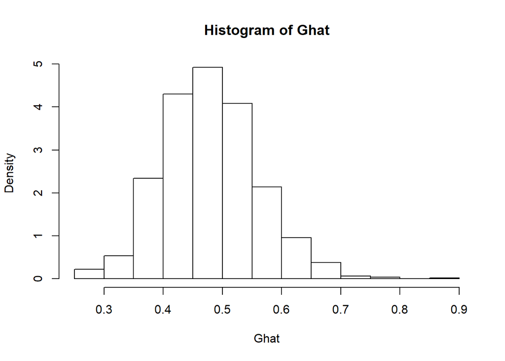

#### Output for uniform distribution

```r
Uniform <- function(n){
  x <- sort(runif(n, 0, 1))
  y <- 2*(1:n) - n - 1
  G <- sum(x*y) / (n^2 * mean(x))
  G
}
output(Uniform)
```

```
## mean G hat: 0.3220587
## median G hat: 0.3196071
## quantile of G hat:
##       10%       20%       30%       40%       50%       60%       70%
## 0.2583947 0.2758006 0.2924939 0.3078254 0.3196071 0.3339500 0.3474526
##       80%       90%      100%
## 0.3660642 0.3927273 0.5072521
```

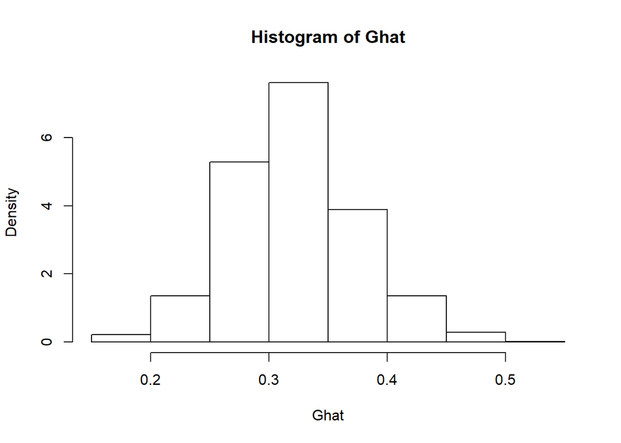

#### Output for Bernoulli(0.1) distribution

```r
Bernoulli <- function(n){
  x <- sort(rbinom(n, 1, 0.1))
  y <- 2*(1:n) - n - 1
  G <- sum(x*y) / (n^2 * mean(x))
  G
}
output(Bernoulli)
```

```
## mean G hat: 0.885034
## median G hat: 0.9
## quantile of G hat:
##  10%  20%  30%  40%  50%  60%  70%  80%  90% 100%
## 0.80 0.85 0.85 0.90 0.90 0.90 0.95 0.95 0.95 0.95
```

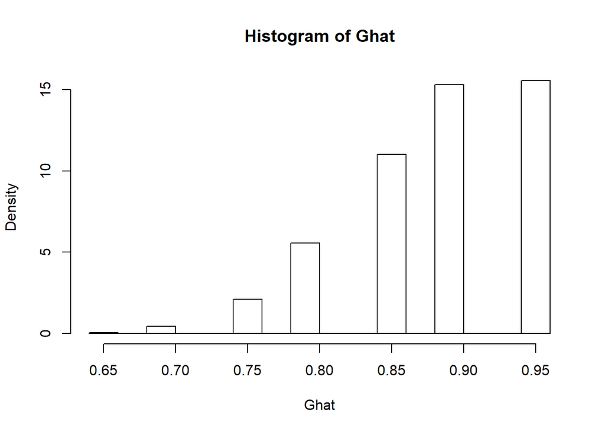

### Exercise 6.10

**Construct an approximate 95% confidence interval for the Gini ratio $\gamma = E[G]$ if $X$ is lognormal with unknown parameters.**

```r
t <- 1000
Ghat <- replicate(t, expr = Lognorm(n = 100))
mean_est <- mean(Ghat)
sd_est <- sd(Ghat)
ucl <- mean_est + 1.96 * sd_est / sqrt(t)
lcl <- mean_est - 1.96 * sd_est / sqrt(t)
cat("A 95% Confidence Interval is [", lcl, ",", ucl, "]\n")
```

```
## A 95% Confidence Interval is [ 0.5105509 , 0.5154545 ]
```

**Assess the coverage rate of the estimation procedure with a Monte Carlo experiment.**

```r
Ghat <- replicate(10000, expr = Lognorm(n = 100))
mean_precise <- mean(Ghat)  # give a relatively more precise est for mean
cover <- replicate(1000,expr = {
  t <- 20
  Ghat <- replicate(t, expr = Lognorm(n = 100))
  mean_est <- mean(Ghat)
  sd_est <- sd(Ghat)
  est <- (mean_est - mean_precise) * sqrt(20) / sd_est
  est > -1.96 & est < 1.96
})
cat("Coverage rate is", mean(cover))
```

```
## Coverage rate is 0.933
```

### Extra Exercise 1

**Suppose $X_1,\cdots,X_n$ are i.i.d. samples from a normal distribution $N(\mu, \sigma^2)$, $n \ge 2$. Prove that $\sum_{i=1}^n(X_i - \bar X)^2 / \sigma^2$ follows $\chi^2(n-1)$ distribution and it is independent with the sample mean $\bar X$.**

$\underline{\boldsymbol{pf}}:$

Since $X_1,\cdots,X_n$ are i.i.d. samples from $N(\mu, \sigma^2)$, then
$$(X_i - \mu) / \sigma \sim N(0,1) \quad
\therefore \sum_{i=1}^n(X_i - \mu)^2 / \sigma^2 \sim \chi^2(n)$$

Note that,
$$\sum_{i=1}^n(X_i - \mu)^2 / \sigma^2 = \sum_{i=1}^n(X_i - \bar X)^2 / \sigma^2 + n(\bar X - \mu)^2 / \sigma^2$$
And
$$\because \bar X \sim N(\mu, \sigma^2/n) \quad
\therefore \sqrt n(\bar X - \mu) / \sigma \sim N(0,1) \quad
\therefore n(\bar X - \mu)^2 / \sigma^2 \sim \chi^2(1)$$
Hence,
$$\sum_{i=1}^n(X_i - \bar X)^2 / \sigma^2 \sim \chi^2(n)-\chi^2(1) = \chi^2(n-1)$$
Q.E.D.

### Extra Exercise 2

**In Example 6.4, to construct a $(1 - \alpha) \times 100\%$ confidence interval for the variance parameter $\sigma^2$, we assume that the lower bound is 0 and the upper bound corresponds to a quantity involving the $\alpha$-quantile of a $\chi^2$ distribution, we now consider using $\alpha/2$ and $(1 - \alpha/2)$-quantiles of the same $\chi^2$ distribution to construct another confidence interval. It certainly will excludes 0.**

**(1) Give the explicit form of the new confidence interval and justify its validity by showing the theoretical confidence level is $1 - \alpha$.**

$\underline{\boldsymbol{solution}}:$

The explicit form of the new confidence interval is
$$\frac{\sum_{i=1}^n(X_i - \bar X)^2}{\chi^2_{1-\alpha/2}(n-1)}
<\sigma^2<
\frac{\sum_{i=1}^n(X_i - \bar X)^2}{\chi^2_{\alpha/2}(n-1)}$$
With this CI, we can get
$$\chi^2_{\alpha/2}(n-1)
<\frac{\sum_{i=1}^n(X_i - \bar X)^2}{\sigma^2}
<\chi^2_{1-\alpha/2}(n-1)$$
Since we have already proved $\sum_{i=1}^n(X_i - \bar X)^2 / \sigma^2 \sim \chi^2(n-1)$ in the last exercise, then the theoretical confidence level is exactly
$${\rm P}\left[
\chi^2_{\alpha/2}(n-1)
<\frac{\sum_{i=1}^n(X_i - \bar X)^2}{\sigma^2}
<\chi^2_{1-\alpha/2}(n-1)
\right]=1-\alpha/2-\alpha/2=1-\alpha$$
Q.E.D.

**(2) Repeat the experiments in Example 6.5 with the same parameter set-up. Compare the two types of confidence interval, such as empirical coverage probability and average confidence interval width.**

```r
# one-tail
n <- 20
alpha <- .05
UCL <- replicate(1000, expr = {
  x <- rnorm(n, mean = 0, sd = 2)
  (n-1) * var(x) / qchisq(alpha, df = n-1)
} )
# two-tail
CI <- replicate(1000, expr = {
  x <- rnorm(n, mean = 0, sd = 2)
  c((n-1) * var(x) / qchisq(1-alpha/2, df = n-1),
    (n-1) * var(x) / qchisq(alpha/2, df = n-1))
} )
# output
cat("For one-tail CI:\n  The empirical coverage probability is ", mean(UCL > 4), "\n  The average confidence interval width is ", mean(UCL), "\nFor two-tail CI:\n  The empirical coverage probability is ", mean(CI[1,] < 4 & CI[2,] > 4), "\n  The average confidence interval width is ", mean(CI[2] - CI[1]))
```

```
## For one-tail CI:
##   The empirical coverage probability is  0.93
##   The average confidence interval width is  7.430056
## For two-tail CI:
##   The empirical coverage probability is  0.947
##   The average confidence interval width is  6.653795
```

**(3) Repeat the experiments in Example 6.6 with the same parameter set-up. Compare the two types of confidence interval, such as empirical coverage probability and average confidence interval width.**

```r
# one-tail
n <- 20
alpha <- .05
UCL <- replicate(1000, expr = {
  x <- rchisq(n, df = 2)
  (n-1) * var(x) / qchisq(alpha, df = n-1)
} )
# two-tail
CI <- replicate(1000, expr = {
  x <- rchisq(n, df = 2)
  c((n-1) * var(x) / qchisq(1-alpha/2, df = n-1),
    (n-1) * var(x) / qchisq(alpha/2, df = n-1))
} )
# output
cat("For one-tail CI:\n  The empirical coverage probability is ", mean(UCL > 4), "\n  The average confidence interval width is ", mean(UCL), "\nFor two-tail CI:\n  The empirical coverage probability is ", mean(CI[1,] < 4 & CI[2,] > 4), "\n  The average confidence interval width is ", mean(CI[2] - CI[1]))
```

```
## For one-tail CI:
##   The empirical coverage probability is  0.799
##   The average confidence interval width is  7.391048
## For two-tail CI:
##   The empirical coverage probability is  0.728
##   The average confidence interval width is  3.59313
```

**(4) Which confidence interval would you recommend in practice? Explain why.**